# AIS2 DSSO report

Mike Trnka

2024-05-09

### Experiment Overview:

##### S20240326

- Wei sent RAT AIS samples crosslinked with 1.5 mM DSSO.
- I don’t have the reported amounts for AIS protein abundance.
- Sample was acetone precipitated (?) and pellet sent to UCSF.
- Brought up pellet in 6N Guanidinium-HCl. Reduced and alkylated with DTT/Iodoacetamine.
- Digestesd first with LysC followed by Trypsin.
- Desalted on Mactrap C18 column. Split into 2 injections.
- The estimated amount of peptide (based on integration of 214 nm UV trace and compared to fetuin std) was ~500 µg.
- Enriched for crosslinks / fractionated on Superdex Peptide SEC column. Estimated peptide abundance from UV trace is ~350 µg.
- SEC Fractions A1-A3 (pooled), A4, A5, A6-A8 (pooled), were further fractionated by high pH reverse phase chromatography (Phenomenex Gemini 3µm C18: 1 x 100 mm). Approximately 36 fractions were collected per injections and pooled (every 7th fraction pooled) to create 6 pools + flow thru + unfractionated.
- Total of ~32 samples (4 SEC x 8 highPH fractions) were run on Orbitrap Exploris MS.
- Acquired MS data on 50 cm column with FAIMS source and stHCD. 4 hour gradients.
- Data were initially searched to identify most abundant proteins. Proteins identified by >1 unique peptides (there were 3019 protein IDs matching this criteria, Table 1), were used in the crosslinking search.

### Technical Problems with the acquisition:

Generally there were many technical problems to contend with througout the workflow on these samples. These included:

- high pressure on the Akta causing leaking and cracking on the mixing chambers
- noise / persistent bubbles on the UV detector of the Akta.
- Injection problems with the Dionex UPLC system resulting in mis-injection when acquiring MS on the Exploris. This necessitated a service call to Thermo after several attempts to fix the injector in-house failed.
- Network/connectivity problems when running the bioinformatics searches causing slow analysis times.

Overall, it took about 7 weeks to go from sample to data. Not all fractions were successfully acquired by MS due to the injector issues mentioned above. Also, the high pH reverse phase separation was suboptimal and inconsistent due to fighting pressure issues.

The figure below shows number of crosslinked spectra (CSMs) at 1% FDR by fraction. Note that A3 fractions were basically empty. The A4 fractions seems to be having some issues as well. In a typical experiment A4 would have the most crosslinks > A5 > A3 > A6. So I think the preponderance of technical issues definitely compromised the quality of this expeirment.

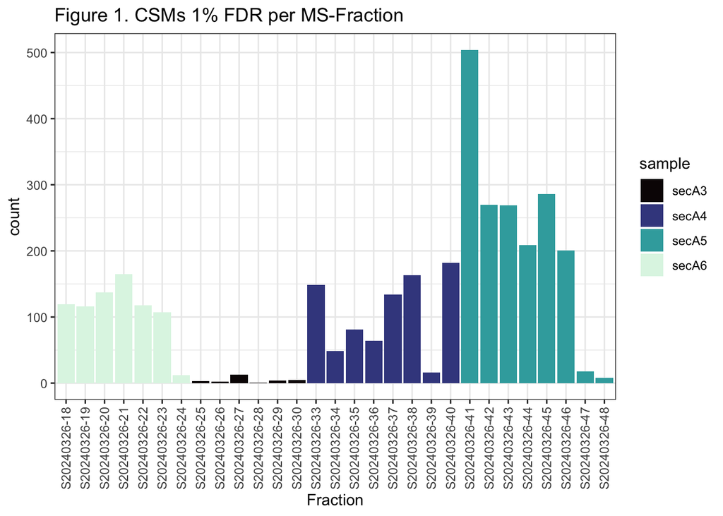

Comparing the same kind of plot for spectral matches to linear peptides (non-crosslinked peptides) shows that as expected, A6 has a higher percentage of PSMs to CSMs compared to A5 (eg, an earlier eluting SEC fraction), but A3 and A4 look very poor indicating technical issues with these two samples. I would expect A4 to have considerably more crosslinks (CSMs) than A5 and slightly less linear peptides (PSMs) than A5. A3 clearly has issues which are caused by a mis-injecting UPLC system. The A4 problems are more subtle but also mainly related to issues with the injection system.

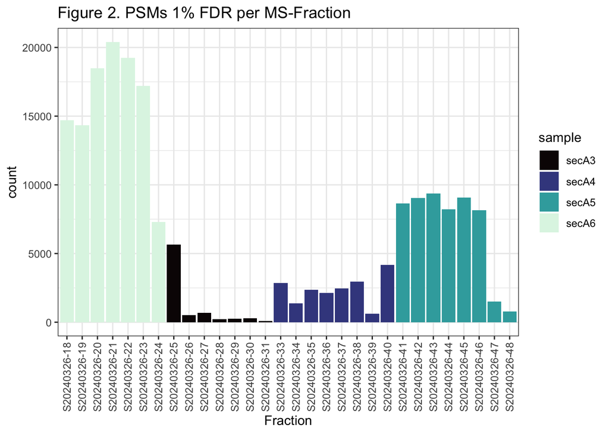

### Results:

Overall, we collected 971,581 MS2 spectra. 168776 of these were matched to linear peptides, 24415 were linear peptides which were dead-end modified by DSSO, and 3405 were matched to crosslinked peptides. The remainder of the MS2 spectra are unmatched.

Table 1 lists the proteins identified in the sample. In the default Protein Prospector rank-order, the protein IDs are sorted by how confidently the best scoring peptide from each protein is identified. In this ranking, we see typical proteins indictive of the axon intial segments. Spectrin is ranked 1st. AnkG is number 27. Trim46 is 171.

*Spectral Abundance Factor (SAF)* is a semi-quantitative metric that reflects protein abundance. When we sort the the protein IDs by SAF, we see that the most abundant proteins are histones, actin, and tubulin. Note that the table is scrollable and the buttons at the bottom of the table should allow you to download/copy the table.

| Rank | SAF | Gene | Acc # | Protein Name | Uniq Pep | Num Unique | Peptide Count | % Cov | Best Expect Val | Protein Length | Species |
| --- | --- | --- | --- | --- | --- | --- | --- | --- | --- | --- | --- |
| 1 | 135.6 | Sptan1 | P16086 | Spectrin alpha chain, non-erythrocytic 1 |  | 428 | 3352 | 82.1 | 3.9e-34 | 2472 | RAT |
| 2 | 19.8 | Macf1 | D3ZHV2 | Microtubule-actin cross-linking factor 1 |  | 354 | 1076 | 49.8 | 4.8e-31 | 5430 | RAT |
| 3 | 88.1 | Map1b | P15205 | Microtubule-associated protein 1B |  | 288 | 2168 | 67.2 | 6.7e-36 | 2461 | RAT |
| 3.1 | 14.1 | Map1a | P34926 | Microtubule-associated protein 1A | 105 | 107 | 390 | 43.5 | 2.8e-36 | 2774 | RAT |
| 4 | 104.9 | Map2 | P15146 | Microtubule-associated protein 2 |  | 254 | 1952 | 77.0 | 2.6e-30 | 1861 | RAT |
| 5 | 22.5 | Dync1h1 | P38650 | Cytoplasmic dynein 1 heavy chain 1 |  | 279 | 1047 | 42.4 | 2.0e-28 | 4644 | RAT |
| 6 | 52.4 | Myh10 | Q9JLT0 | Myosin-10 |  | 248 | 1036 | 62.2 | 6.6e-28 | 1976 | RAT |
| 6.1 | 13.3 | Myh9 | Q62812 | Myosin-9 | 96 | 116 | 261 | 41.7 | 4.0e-24 | 1961 | RAT |
| 6.2 | 3.2 | Myh11 | Q63862 | Myosin-11 (Fragments) | 10 | 21 | 42 | 16.6 | 9.2e-21 | 1327 | RAT |
| 7 | 1643.4 | Tubb2b | Q3KRE8 | Tubulin beta-2B chain |  | 182 | 7313 | 76.6 | 4.4e-36 | 445 | RAT |

[output cut: 3009 more lines]

The CLMS analysis was restricted to the 3019 proteins identified above. Crosslinks are reported as *unique residue pairs (URPs)*. The FDR plot in Figure 3 shows that a score threshold was chosen to discriminate between random/decoy matches and correct matches. This score threshold is set such that we expect about 5% of the URPs in our list to be incorrect.

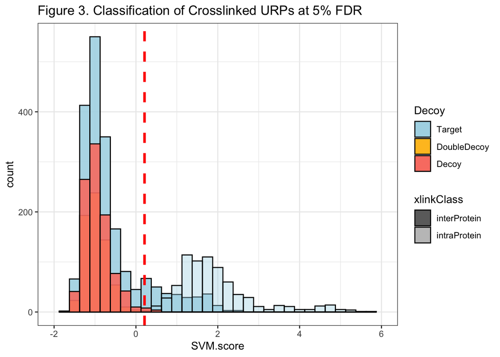

Table 2. FDR analysis of URPs

| xlinkClass | Decoy | DoubleDecoy | Target |
| --- | --- | --- | --- |
| interProtein | 21 | 1 | 280 |
| intraProtein | 2 |  | 723 |

The full list of 1003 crosslinked URPs is presented in the table below. There are buttons to facilitate downloading the data beneath the table and the table is scrollable / sortable. Hyperlinks ot the supporting spectral annotations are provided. SVM.score reports on the quality of the spectral evidence, with higher numbers indicating that a crosslink is more likely to be annotated correctly. Sorting based on the column “xlinkClass” will facilitate looking only at inter-protein crosslinks.

| specMS2 | ProteinPair | xlinkedResPair | SVM.score | Acc.1 | Acc.2 | XLink.AA.1 | XLink.AA.2 | DB.Peptide.1 | DB.Peptide.2 | Decoy | xlinkedProtPair | m/z | z | ppm | Score | Score.Diff | percMatched | Sc.1 | Rk.1 | Sc.2 | Rk.2 | Protein.1 | Species.1 | Protein.2 | Species.2 | xlinkClass | Len.Pep.1 | Len.Pep.2 | Peptide.1 | … |
| --- | --- | --- | --- | --- | --- | --- | --- | --- | --- | --- | --- | --- | --- | --- | --- | --- | --- | --- | --- | --- | --- | --- | --- | --- | --- | --- | --- | --- | --- | --- |
| <a href="https://msviewer.ucsf.edu/cgi-bin/mssearch.cgi?search_name=msproduct&output_type=HTML&report_title=MS-Product&version=6.2.29&data_source=Data%20From%20File&data_filename=%2fvar%2flib%2fprospe… | 10 kDa heat shock protein, mitochondrial::10 kDa heat shock protein, mitochondrial | 28.P26772::70.P26772 | 1.93 | P26772 | P26772 | 28 | 70 | SAAETVTKGGIMLPEK | VGDKVLLPEYGGTK | Target | P26772::P26772 | 820.9254 | 4 | 3.2 | 45.2 | 22.4 | 89.3 | 22.8 | 1 | 21.7 | 2 | 10 kDa heat shock protein, mitochondrial | RAT | 10 kDa heat shock protein, mitochondrial | RAT | intraProtein | 16 | 14 | SAAETVTK(+DSSO*)GGIM(Oxidation)LPEK | … |
| <a href="https://msviewer.ucsf.edu/cgi-bin/mssearch.cgi?search_name=msproduct&output_type=HTML&report_title=MS-Product&version=6.2.29&data_source=Data%20From%20File&data_filename=%2fvar%2flib%2fprospe… | 10 kDa heat shock protein, mitochondrial::10 kDa heat shock protein, mitochondrial | 70.P26772::8.P26772 | 1.37 | P26772 | P26772 | 70 | 8 | VGDKVLLPEYGGTK | KFLPLFDR | Target | P26772::P26772 | 667.8592 | 4 | 3.6 | 40.1 | 15.5 | 77.3 | 20.5 | 3 | 14.1 | 23 | 10 kDa heat shock protein, mitochondrial | RAT | 10 kDa heat shock protein, mitochondrial | RAT | intraProtein | 14 | 8 | VGDK(+DSSO*)VLLPEYGGTK | … |
| <a href="https://msviewer.ucsf.edu/cgi-bin/mssearch.cgi?search_name=msproduct&output_type=HTML&report_title=MS-Product&version=6.2.29&data_source=Data%20From%20File&data_filename=%2fvar%2flib%2fprospe… | 14-3-3 protein gamma::14-3-3 protein gamma | 69.P61983::78.P61983 | 1.5 | P61983 | P61983 | 69 | 78 | VISSIEQKTSADGNEK | KIEMVR | Target | P61983::P61983 | 660.3322 | 4 | 0.3 | 32.6 | 12.7 | 80.7 | 18.2 | 3 | 5.3 | 270 | 14-3-3 protein gamma | RAT | 14-3-3 protein gamma | RAT | intraProtein | 16 | 6 | VISSIEQK(+DSSO*)TSADGNEK | … |
| <a href="https://msviewer.ucsf.edu/cgi-bin/mssearch.cgi?search_name=msproduct&output_type=HTML&report_title=MS-Product&version=6.2.29&data_source=Data%20From%20File&data_filename=%2fvar%2flib%2fprospe… | 14-3-3 protein theta::14-3-3 protein theta | 68.P68255::75.P68255 | 1.77 | P68255 | P68255 | 68 | 75 | VISSIEQKTDTSDK | KLQLIK | Target | P68255::P68255 | 613.3323 | 4 | 0.68 | 41.7 | 13.7 | 89.9 | 28 | 1 | 10.1 | 59 | 14-3-3 protein theta | RAT | 14-3-3 protein theta | RAT | intraProtein | 14 | 6 | VISSIEQK(+DSSO*)TDTSDK | … |
| <a href="https://msviewer.ucsf.edu/cgi-bin/mssearch.cgi?search_name=msproduct&output_type=HTML&report_title=MS-Product&version=6.2.29&data_source=Data%20From%20File&data_filename=%2fvar%2flib%2fprospe… | 14-3-3 protein theta::14-3-3 protein theta | 11.P68255::3.P68255 | 1.71 | P68255 | P68255 | 11 | 3 | AKLAEQAER | MEKTELIQK | Target | P68255::P68255 | 778.7276 | 3 | 0.069 | 47.2 | 16.3 | 84.1 | 21.8 | 5 | 20.1 | 8 | 14-3-3 protein theta | RAT | 14-3-3 protein theta | RAT | intraProtein | 9 | 9 | AK(+DSSO*)LAEQAER | … |
| <a href="https://msviewer.ucsf.edu/cgi-bin/mssearch.cgi?search_name=msproduct&output_type=HTML&report_title=MS-Product&version=6.2.29&data_source=Data%20From%20File&data_filename=%2fvar%2flib%2fprospe… | 14-3-3 protein theta::14-3-3 protein theta | 115.P68255::122.P68255 | 1.29 | P68255 | P68255 | 115 | 122 | YLIANATNPESKVFYLK | MKGDYFR | Target | P68255::P68255 | 765.8766 | 4 | 0.069 | 30.5 | 14.3 | 66.6 | 16.1 | 2 | 9 | 195 | 14-3-3 protein theta | RAT | 14-3-3 protein theta | RAT | intraProtein | 17 | 7 | YLIANATNPESK(+DSSO*)VFYLK | … |
| <a href="https://msviewer.ucsf.edu/cgi-bin/mssearch.cgi?search_name=msproduct&output_type=HTML&report_title=MS-Product&version=6.2.29&data_source=Data%20From%20File&data_filename=%2fvar%2flib%2fprospe… | 14-3-3 protein theta::Iron-sulfur cluster assembly 1 homolog, mitochondrial | 36.Q80W96::68.P68255 | 0.58 | P68255 | Q80W96 | 68 | 36 | VISSIEQKTDTSDK | IKQLLK | Target | P68255::Q80W96 | 613.3319 | 4 | 0.038 | 30.6 | 11.8 | 87.4 | 18.8 | 1 | 12.1 | 32 | 14-3-3 protein theta | RAT | Iron-sulfur cluster assembly 1 homolog, mitochondrial | RAT | interProtein | 14 | 6 | VISSIEQK(+DSSO*)TDTSDK | … |
| <a href="https://msviewer.ucsf.edu/cgi-bin/mssearch.cgi?search_name=msproduct&output_type=HTML&report_title=MS-Product&version=6.2.29&data_source=Data%20From%20File&data_filename=%2fvar%2flib%2fprospe… | 14-3-3 protein zeta/delta::14-3-3 protein zeta/delta | 11.P63102::68.P63102 | 1.69 | P63102 | P63102 | 11 | 68 | AKLAEQAER | VVSSIEQKTEGAEK | Target | P63102::P63102 | 670.0888 | 4 | -0.56 | 41.3 | 15 | 80.9 | 23 | 2 | 12.5 | 45 | 14-3-3 protein zeta/delta | RAT | 14-3-3 protein zeta/delta | RAT | intraProtein | 9 | 14 | AK(+DSSO*)LAEQAER | … |
| <a href="https://msviewer.ucsf.edu/cgi-bin/mssearch.cgi?search_name=msproduct&output_type=HTML&report_title=MS-Product&version=6.2.29&data_source=Data%20From%20File&data_filename=%2fvar%2flib%2fprospe… | 14-3-3 protein zeta/delta::14-3-3 protein zeta/delta | 11.P63102::3.P63102 | 1.61 | P63102 | P63102 | 11 | 3 | AKLAEQAER | MDKNELVQK | Target | P63102::P63102 | 779.0463 | 3 | -1.1 | 35.3 | 11.8 | 81.8 | 18.4 | 5 | 11.6 | 17 | 14-3-3 protein zeta/delta | RAT | 14-3-3 protein zeta/delta | RAT | intraProtein | 9 | 9 | AK(+DSSO*)LAEQAER | … |
| <a href="https://msviewer.ucsf.edu/cgi-bin/mssearch.cgi?search_name=msproduct&output_type=HTML&report_title=MS-Product&version=6.2.29&data_source=Data%20From%20File&data_filename=%2fvar%2flib%2fprospe… | 14-3-3 protein zeta/delta::14-3-3 protein zeta/delta | 115.P63102::122.P63102 | 1.52 | P63102 | P63102 | 115 | 122 | FLIPNASQPESKVFYLK | MKGDYYR | Target | P63102::P63102 | 768.3818 | 4 | 0.019 | 36.2 | 14.5 | 75 | 21.7 | 1 | 12.5 | 128 | 14-3-3 protein zeta/delta | RAT | 14-3-3 protein zeta/delta | RAT | intraProtein | 17 | 7 | FLIPNASQPESK(+DSSO*)VFYLK | … |

[output cut: 993 more lines]

### Initial Thoughts on Experiment:

- Majority of crosslinks are intraProtein (see Table 2).
- Amongst interProtein crosslinks, a large number are between different histone subunits.
- Other interProtein crosslinks are mostly between established interaction partners: eg Alpha-internexin to Neurofilament Proteins or between Dpysl subunits.
- On the one hand, this indicates that data is of high quality.
- On the other hand, we don’t seem to be digging deep enough to find the more interesting interactions.
- There are many crosslinks from nuclear (histone, heterochromatin binders, etc) or mitochondrial proteins (ATP-sythetase, MICOS) present, which is not expected for the detergent-treated axon initial segment preps.
- Histones were also some of the most abundant proteins identified in the sample by SAF (Table 1).
- There are some Spectrin alpha/beta chain crosslinks and a single AnkG/AnkG crosslink which are indicative of AIS. Numerous crosslinks to cytoskeletal proteins seem consistent with AIS (actin, tubulin, etc).
- Juan and I were speculating that, that the crosslinking procedure followed by the precipitation may be causing the AIS machinery to disproportionately aggregate (relative to more soluble nuclear proteins, for instance). These then become difficult to resolubilize for CLMS analysis.
- It might be necessary to re-think the experimental conditions, including going back to lower concentrations of DSSO and removing the acetone precripitation step.
- An enrichable crosslinker, such as [DSBSO](https://www.sigmaaldrich.com/US/en/product/aldrich/909629), might allow us to dig deeper into the AIS crosslinked interactome.
- As mentioned above, the experiment was beset with technical malfunctions. We might have seen 50-100% more crosslinks if all hardware had worked correctly.